# **Project - Classification and Hypothesis Testing: Hotel Booking Cancellation Prediction**

### **Question 7: Random Forest (4 Marks)**

#### **Question 7.1: Build a Random Forest Model (1 Mark)**

```python
# Remove _________ and complete the code

rf_estimator = RandomForestClassifier(class_weight = {0: 0.67, 1: 0.33}, random_state = 1)

rf_estimator.fit(X_train, y_train)
```

```
RandomForestClassifier(class_weight={0: 0.67, 1: 0.33}, random_state=1)
```

#### **Question 7.2: Check the performance of the model on the train and test data (2 Marks)**

```
              precision    recall  f1-score   support

           0       0.99      1.00      1.00     17073
           1       1.00      0.98      0.99      8319

    accuracy                           0.99     25392
   macro avg       1.00      0.99      0.99     25392
weighted avg       0.99      0.99      0.99     25392
```

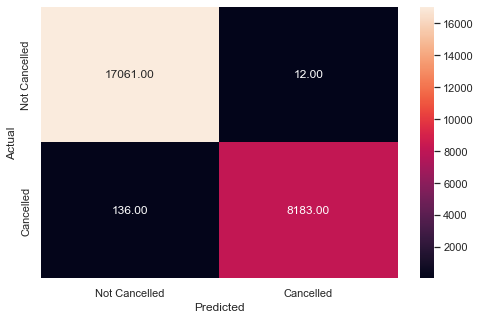

```python
# Remove _________ and complete the code

y_pred_train_rf = rf_estimator.predict(X_train)

metrics_score(y_train, y_pred_train_rf)
```

**Write your answers here:** The performance of Random Forest model on training dataset is very good. The precision, recall, F1-score and accuracy is very high, approximately 100%.

```
              precision    recall  f1-score   support

           0       0.91      0.95      0.93      7317
           1       0.88      0.80      0.84      3566

    accuracy                           0.90     10883
   macro avg       0.89      0.87      0.88     10883
weighted avg       0.90      0.90      0.90     10883
```

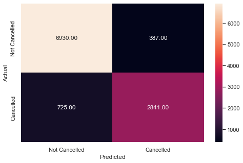

```python
# Remove _________ and complete the code

y_pred_test_rf = rf_estimator.predict(X_test)

metrics_score(y_test, y_pred_test_rf)
```

#### **Question 7.3: What are some important features based on the Random Forest? (1 Mark)**

Let's check the feature importance of the Random Forest

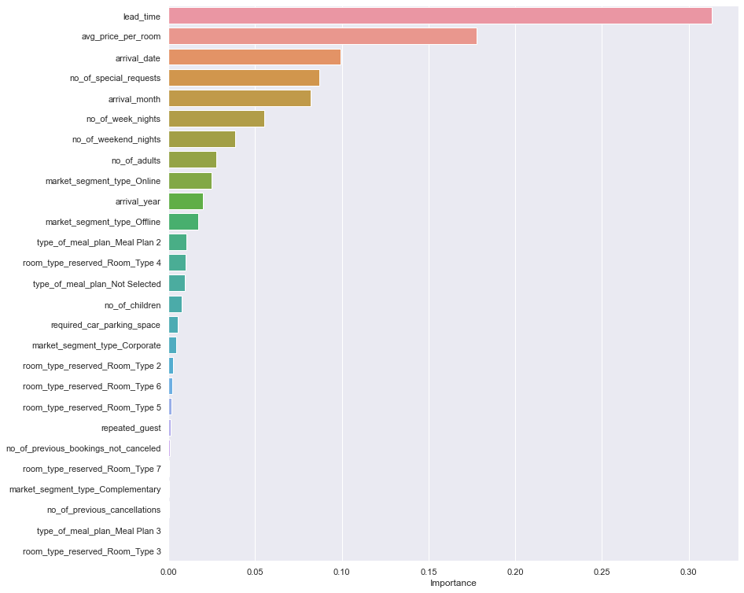

```python
# Remove _________ and complete the code

importances = rf_estimator.feature_importances_

columns = X.columns

importance_df = pd.DataFrame(importances, index = columns, columns = ['Importance']).sort_values(by = 'Importance', ascending = False)

plt.figure(figsize = (13, 13))

sns.barplot(importance_df.Importance, importance_df.index)
```

**Write your answers here:**

1. The most imprtant feature is "lead_time".
2. The "avg_price_per_room" is the 2nd important feature.
3. Besides, there are some other important features "arrival_date", "no_of_special_requests", and "arrival_month".

### **Question 8: Conclude ANY FOUR key takeaways for business recommendations (4 Marks)**

**Write your answers here:** According to the important features of Random Forest model,

1. Hotel management should emphasize the period between booking and the arrival date of customer. In this case, the management should plan to shorter the period.
2. To avoid unexpected cancellations, hotel management can reduce the average price per room or manage uniform low average price per room.
3. Hotel management can focus on arrival month and arrival date in such a way that the booking only opens close to the most frequent arrival date and on that specific month hotel management should offer more facility to the customer to avoid unexpected cancellations.
4. To avoid unexpected booking cancellations, the facility of hotel could be improved based on the number of special requests and number of stayed days (number of weekend nights + week nights).